### Simple Regression Analysis

*Yuyu Zhang*

#### **Abstract**

Linear regression is an important approach in modeling. In this report we reproduce the main results presented in section 3.1 *Simple Linear Regression* of the book **An Introduction to Statistical Learning**

#### **Introduction**

The overall goal is to provide advice on how to improve sales of the particular product. More specifically, the idea is to determine whether there is an association between advertising and sales, and if so, develop an accurate model that can be used to predict sales on the basis of the three media budgets.

#### **Data**

The Advertising data set consists of the **Sales** (in thousands of units) of a particular product in 200 different markets, along with advertising budgets (in thousands of dollars) for the product in each of those markets for three different media: **TV,** **Radio**, and **Newspaper**.

#### **Methodology**

We consider one media from the data set, **TV**, and study its relationship with **Sales**. For this purpose, we use a simple linear model: Sales= $\beta$*0+ $\beta$*1*TV To estimate the coefficients $\beta$*0 and $\beta$*1 we fit a regression model via the least squares criterion

#### **Results**

We compute the regression coefficients. The regression coefficients is summarized in Table 1 below:

Table 1: Information about regression coefficients

|  | Estimate | Std. Error | t value | Pr(>\|t\|) |
| --- | --- | --- | --- | --- |
| (Intercept) | 7.03 | 0.46 | 15.36 | 0.00 |
| TV | 0.05 | 0.00 | 17.67 | 0.00 |

The scatterplot of the fitted regression line is shown in Figure below.

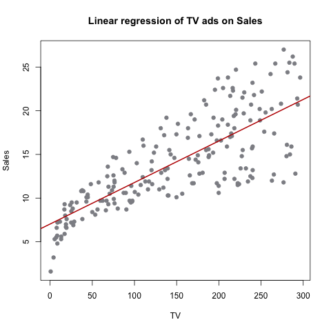

#### **Conclusion**

In conclusion, by taking data and using linear regression model, computing all relevant coefficients, we see a relatively linear relationship between TV ads and sales, and hence a non-trivial effects of TV advertising on product sales.

#### **Acknowledgement**

I would like to thank the author of the book **An Introduction to Statistical Learning** Gareth James, who provides the data and such a valuable practice lesson. I would also like to thanks the TA and professor for providing help to finis this assignment.